# Segmented regression of age-standardised mortality rates - Scotland all-ages Q1 1990 to Q2 2018

## Generate linear model for both sexes

```r
tidied_allagerates_2018 %>%
  rename(rate = Rate) %>%
  filter(sex == "M") -> allagemale
  lm(rate ~ time, data = allagemale) -> lmod_male_2018
tidied_allagerates_2018 %>%
  rename(rate = Rate) %>%
  filter(sex == "F") -> allagefemale
  lm(rate ~ time, data = allagefemale) -> lmod_female_2018
```

## View linear model

```r
summary (lmod_male_2018)
```

```
Call:
lm(formula = rate ~ time, data = allagemale)

Residuals:
   Min     1Q Median     3Q    Max
-70.61 -35.95 -16.73  38.07 136.87

Coefficients:
              Estimate Std. Error t value Pr(>|t|)
(Intercept) 68692.8757  1149.5331   59.76   <2e-16 ***
time          -33.4299     0.5734  -58.30   <2e-16 ***
---
Signif. codes:  0 ‘***’ 0.001 ‘**’ 0.01 ‘*’ 0.05 ‘.’ 0.1 ‘ ’ 1

Residual standard error: 48.4 on 109 degrees of freedom
Multiple R-squared:  0.9689,    Adjusted R-squared:  0.9686
F-statistic:  3399 on 1 and 109 DF,  p-value: < 2.2e-16
```

```r
summary (lmod_female_2018)
```

```
Call:
lm(formula = rate ~ time, data = allagefemale)

Residuals:
    Min      1Q  Median      3Q     Max
-59.212 -20.876  -2.675  16.528  82.259

Coefficients:
             Estimate Std. Error t value Pr(>|t|)
(Intercept) 33602.621    689.556   48.73   <2e-16 ***
time          -16.179      0.344  -47.03   <2e-16 ***
---
Signif. codes:  0 ‘***’ 0.001 ‘**’ 0.01 ‘*’ 0.05 ‘.’ 0.1 ‘ ’ 1

Residual standard error: 29.03 on 109 degrees of freedom
Multiple R-squared:  0.953, Adjusted R-squared:  0.9526
F-statistic:  2212 on 1 and 109 DF,  p-value: < 2.2e-16
```

## Get trend line of linear model fit to whole timeseries

A linear trend line fitted to the whole data series demonstrates the overall decline in mortality rates, and the steeper decline in men than women. For both sexes the recent observed data lie above the linear trend line.

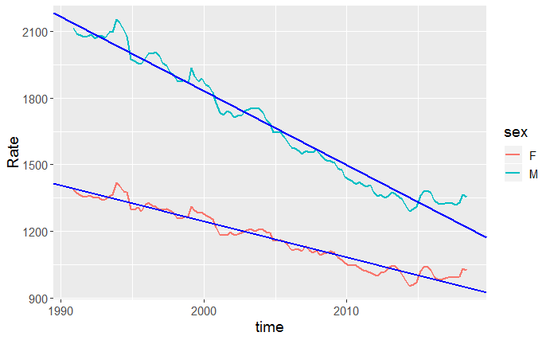

```r
my.coeftrendlinemale_2018 <- coef(lmod_male_2018)
my.coeftrendlinefemale_2018 <- coef(lmod_female_2018)
addtrendline <- plot + geom_abline(intercept = my.coeftrendlinemale_2018[1], col="Blue", size=1.0001,
                                       slope = my.coeftrendlinemale_2018[2],
                                       aes(colour = "Overall"))+
  geom_abline(intercept = my.coeftrendlinefemale_2018[1], col="Blue", size=1.0001,
                                       slope = my.coeftrendlinefemale_2018[2],
                                       aes(colour = "Overall"))
addtrendline
```

# Segmented regression

```r
davies_allmale_2018 = davies.test(lmod_male_2018, ~time, k=111)
davies_allfemale_2018 = davies.test(lmod_female_2018, ~time, k=111)
davies_allmale_2018
```

```
    Davies' test for a change in the slope

data:  formula = rate ~ time ,   method = lm
model = gaussian , link = identity
segmented variable = time
'best' at = 2013.7, n.points = 109, p-value = 6.176e-16
alternative hypothesis: two.sided
```

```r
davies_allfemale_2018
```

```
    Davies' test for a change in the slope

data:  formula = rate ~ time ,   method = lm
model = gaussian , link = identity
segmented variable = time
'best' at = 2014.4, n.points = 109, p-value = 1.932e-08
alternative hypothesis: two.sided
```

## Segmented regression - one breakpoint model

The same breakpoint is identifed for men and women as with the Davies test.

```r
 my.seg_male_2018<-segmented(  lmod_male_2018, seg_rate.Z = ~time, psi = NA, control = seg.control(K=1))
 my.seg_female_2018<-segmented(  lmod_female_2018, seg_rate.Z = ~time, psi = NA, control = seg.control(K=1))

summary(my.seg_male_2018)
```

```
    ***Regression Model with Segmented Relationship(s)***

Call:
segmented.lm(obj = lmod_male_2018, psi = NA, control = seg.control(K = 1),
    seg_rate.Z = ~time)

Estimated Break-Point(s):
     Est.   St.Err
2013.773    0.436

Meaningful coefficients of the linear terms:
              Estimate Std. Error t value Pr(>|t|)
(Intercept) 74830.5557  1087.9900  68.779   <2e-16 ***
time          -36.4997     0.5434 -67.171   <2e-16 ***
U1.time        39.7839     5.8228   6.832       NA
---
Signif. codes:  0 ‘***’ 0.001 ‘**’ 0.01 ‘*’ 0.05 ‘.’ 0.1 ‘ ’ 1

Residual standard error: 34.6 on 107 degrees of freedom
Multiple R-Squared: 0.9844,  Adjusted R-squared: 0.984

Convergence attained in 3 iterations with relative change 0
```

```r
summary(my.seg_female_2018)
```

```
    ***Regression Model with Segmented Relationship(s)***

Call:
segmented.lm(obj = lmod_female_2018, psi = NA, control = seg.control(K = 1),
    seg_rate.Z = ~time)

Estimated Break-Point(s):
     Est.   St.Err
2014.374    0.565

Meaningful coefficients of the linear terms:
              Estimate Std. Error t value Pr(>|t|)
(Intercept) 36228.2003   744.1298  48.685   <2e-16 ***
time          -17.4921     0.3716 -47.073   <2e-16 ***
U1.time        22.0008     4.8540   4.533       NA
---
Signif. codes:  0 ‘***’ 0.001 ‘**’ 0.01 ‘*’ 0.05 ‘.’ 0.1 ‘ ’ 1

Residual standard error: 24.44 on 107 degrees of freedom
Multiple R-Squared: 0.9673,  Adjusted R-squared: 0.9664

Convergence attained in 3 iterations with relative change -1.142665e-16
```

## Extract breakpoint and 95% confidence intervals for one break model

The standard error is used to calcuate an upper and lower 95% confidence intervals. These are presented below.

```r
breakpointmale_2018 <- my.seg_male_2018$psi[, 2]
breakpointfemale_2018 <- my.seg_female_2018$psi[, 2]
breakpoint_SEmale_2018 <- my.seg_male_2018$psi[, 3]
breakpoint_SEfemale_2018 <- my.seg_female_2018$psi[, 3]
breakpoint_low_CImale_2018 <- breakpointmale_2018 - (breakpoint_SEmale_2018*1.96)
breakpoint_up_CImale_2018 <- breakpointmale_2018 + (breakpoint_SEmale_2018*1.96)
breakpoint_low_CIfemale_2018 <- breakpointfemale_2018 - (breakpoint_SEfemale_2018*1.96)
breakpoint_up_CIfemale_2018 <- breakpointfemale_2018 + (breakpoint_SEfemale_2018*1.96)
breakpointmale_2018
```

```
[1] 2013.773
```

```r
breakpoint_low_CImale_2018
```

```
[1] 2012.918
```

```r
breakpoint_up_CImale_2018
```

```
[1] 2014.628
```

```r
breakpointfemale_2018
```

```
[1] 2014.374
```

```r
breakpoint_low_CIfemale_2018
```

```
[1] 2013.266
```

```r
breakpoint_up_CIfemale_2018
```

```
[1] 2015.483
```

## Generate and plot predicted values from one break model

The ‘fitted’ function is used to predict values for ASMR based on the one break segmented regression model. These predicted values are plotted below.

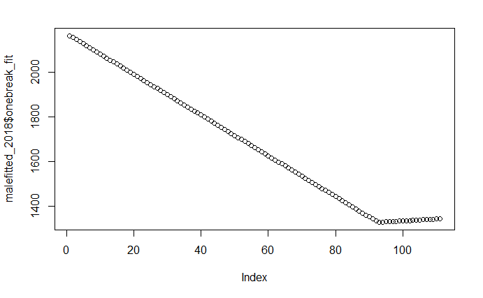

```r
tidied_allagerates_2018 %>%
  filter(sex == "M") %>%
  mutate(
    onebreak_fit = fitted(
      my.seg_male_2018

      )
    ) -> malefitted_2018
tidied_allagerates_2018 %>%
  filter(sex == "F") %>%
  mutate(
    onebreak_fit = fitted(
      my.seg_female_2018
      )
    ) -> femalefitted_2018
plot(malefitted_2018$onebreak_fit)
```

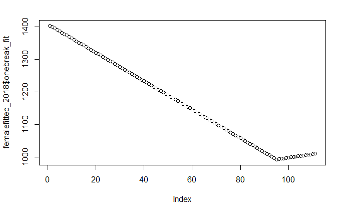

```r
plot(femalefitted_2018$onebreak_fit)
```

## Combine male and female observed and predicted values in single data frame

```r
femalefitted_2018 %>%
  select(
    time, sex, observed = Rate,
    predicted = onebreak_fit
  ) %>%
  bind_rows(
    malefitted_2018 %>%
      select(
        time, sex, observed = Rate,
        predicted = onebreak_fit
      )
  ) -> obs_fit_both_2018
age <- "all"
obs_fit_both_2018$agegroup = age
obs_fit_both_2018
```

| time | sex | observed | predicted | agegroup |
| --- | --- | --- | --- | --- |
| 1990.875 | F | 1386.2 | 1403.6322 | all |
| 1991.125 | F | 1371.0 | 1399.2592 | all |
| 1991.375 | F | 1362.0 | 1394.8862 | all |
| 1991.625 | F | 1356.4 | 1390.5131 | all |
| 1991.875 | F | 1359.8 | 1386.1401 | all |
| 1992.125 | F | 1358.6 | 1381.7671 | all |
| 1992.375 | F | 1349.8 | 1377.3941 | all |
| 1992.625 | F | 1354.1 | 1373.0210 | all |
| 1992.875 | F | 1341.6 | 1368.6480 | all |
| 1993.125 | F | 1345.7 | 1364.2750 | all |

[output cut: 212 more lines]

## Plot observed values with linear and segmented models

The observed data are presented as data points, and the lines indicate the predicted values, according to the one break segmented model.

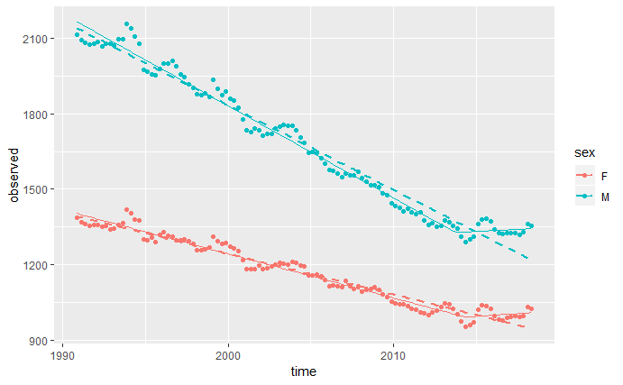

```r
obs_fit_both_2018 %>%
  ggplot(
    aes (x=time, color=sex)
  ) +
  geom_point(
    aes (y=observed)) +
  geom_line (
    aes (y=predicted)) +
  stat_smooth(method="lm",se=F,linetype="dashed",
    aes (y=observed)
  )
```

## Get segmented regression coefficients

Coefficients are used in order to be able to plot a continuation of the pre-break point trend. This differs slightly from the overall linear model, as it does not include the post-breakpoint data.

```r
coef(my.seg_male_2018)
```

```
(Intercept)        time     U1.time   psi1.time
74830.55570   -36.49966    39.78387     0.00000
```

```r
coef(my.seg_female_2018)
```

```
(Intercept)        time     U1.time   psi1.time
36228.20029   -17.49209    22.00080     0.00000
```

```r
# Get coeffiencents male
  b0_aspec_m_2018 <- coef(my.seg_male_2018)[[1]]
  b1_aspec_m_2018 <- coef(my.seg_male_2018)[[2]]
  c1_aspec_m_2018 <- coef(my.seg_male_2018)[[2]] + coef(my.seg_male_2018)[[3]]

  break1_aspec_m_2018 <- my.seg_male_2018$psi[[2]]

# Get coefficients female
  b0_aspec_f_2018 <- coef(my.seg_female_2018)[[1]]
  b1_aspec_f_2018 <- coef(my.seg_female_2018)[[2]]
  c1_aspec_f_2018 <- coef(my.seg_female_2018)[[2]] + coef(my.seg_female_2018)[[3]]

  break1_aspec_f <- my.seg_female_2018$psi[[2]]
```

## Annotated plot of observed data, segmented model, and continutation of pre-breakpoint trend

[figure not shown]

```r
 p <- obs_fit_both_2018 %>%
  ggplot(
    aes (x=time, color=sex)
  ) +
  geom_point(
   aes (y=observed), alpha=0.4) +
  geom_line (
   aes (y=predicted), size=1) +
  geom_abline(intercept = b0_aspec_m_2018, slope = b1_aspec_m_2018, color="#00BFC4", linetype="dashed") +
   geom_abline(intercept = b0_aspec_f_2018, slope = b1_aspec_f_2018, color="#F8766D", linetype= "dashed") +
    ylim(0,2300)+
    labs(x="Year", y="Age-standardised mortality rate", title =
       "Age-standardised quarterly rolling annual mortality rates
        and fitted segmented model, males and females, all ages,
        Scotland, 1990 to 2017") +
    scale_x_continuous (breaks=c(1990, 1994, 1998, 2002, 2006, 2010, 2014, 2018))+
      geom_vline(xintercept = my.seg_male_2018[["psi"]][[2]], color = "#00BFC4", linetype="dotdash")+
   geom_vline(xintercept = my.seg_female_2018[["psi"]][[2]], color = "#F8766D", linetype="dotdash") +
   annotate(geom="text", x=2011, y=250, label="Male\nbreakpoint\nOct 2012-\n Sep 2013 ")+
  annotate(geom="text", x=2017, y=250, label="Female\nbreakpoint\nJuly 2013-\nJune2014")


plot(p)

   ggsave (
    "Figures/Segmentedplot_Scotland_Allagesto2018.png", height=15, width=20, units="cm")
```

## Segmented regression with two breakpoints

Allowing the model to break at two points identifies a breakpoint in quarter 4 of 1993 for both men and women, indicating the year Jan-Dec 1993. The time period identified for the later breakpoint is unchanged for females (Q2 2014), but occurs one year earlier for males (Q4 2012).

```r
my.seg_male2_2018 <-segmented( lmod_male_2018, seg_rate.Z = ~timepoint, psi = NA, control = seg.control(K=2))
my.seg_female2_2018<- segmented(lmod_female_2018, seg_rate.Z = ~timepoint, psi = NA, control = seg.control(K=2))
summary(my.seg_male2_2018)
```

```
    ***Regression Model with Segmented Relationship(s)***

Call:
segmented.lm(obj = lmod_male_2018, psi = NA, control = seg.control(K = 2),
    seg_rate.Z = ~timepoint)

Estimated Break-Point(s):
               Est. St.Err
psi1.time 1993.818  0.534
psi2.time 2012.780  0.397

Meaningful coefficients of the linear terms:
             Estimate Std. Error t value Pr(>|t|)
(Intercept)  6585.840  20230.400   0.326    0.745
time           -2.259     10.155  -0.223    0.824
U1.time       -36.385     10.174  -3.576       NA
U2.time        36.208      3.870   9.357       NA

Residual standard error: 30.36 on 105 degrees of freedom
Multiple R-Squared: 0.9882,  Adjusted R-squared: 0.9877

Convergence attained in 3 iterations with relative change -1.503908e-16
```

```r
summary(my.seg_female2_2018)
```

```
    ***Regression Model with Segmented Relationship(s)***

Call:
segmented.lm(obj = lmod_female_2018, psi = NA, control = seg.control(K = 2),
    seg_rate.Z = ~timepoint)

Estimated Break-Point(s):
               Est. St.Err
psi1.time 1993.851  0.818
psi2.time 2014.382  0.523

Meaningful coefficients of the linear terms:
              Estimate Std. Error t value Pr(>|t|)
(Intercept)  1692.3089 15281.9149   0.111    0.912
time           -0.1655     7.6707  -0.022    0.983
U1.time       -18.1180     7.6822  -2.358       NA
U2.time        24.8288     4.9924   4.973       NA

Residual standard error: 22.93 on 105 degrees of freedom
Multiple R-Squared: 0.9718,  Adjusted R-squared: 0.9704

Convergence attained in 13 iterations with relative change 0
```

## AIC and BIC to compare one and two break models

The lower AIC and BIC indicate that the two break models are a better fit than the one break model for both males and females.

```r
AIC(my.seg_male_2018, my.seg_male2_2018)
```

|  | df | AIC |
| --- | --- | --- |
| my.seg_male_2018 | 5 | 1107.683 |
| my.seg_male2_2018 | 7 | 1080.533 |

```r
AIC(my.seg_female_2018, my.seg_female2_2018)
```

|  | df | AIC |
| --- | --- | --- |
| my.seg_female_2018 | 5 | 1030.486 |
| my.seg_female2_2018 | 7 | 1018.258 |

```r
BIC(my.seg_male_2018, my.seg_male2_2018)
```

|  | df | BIC |
| --- | --- | --- |
| my.seg_male_2018 | 5 | 1121.231 |
| my.seg_male2_2018 | 7 | 1099.500 |

```r
BIC(my.seg_female_2018, my.seg_female2_2018)
```

|  | df | BIC |
| --- | --- | --- |
| my.seg_female_2018 | 5 | 1044.034 |
| my.seg_female2_2018 | 7 | 1037.225 |

## Generate and plot predicted values for two break model

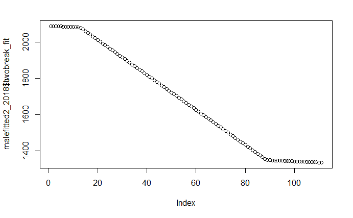

```r
tidied_allagerates_2018 %>%
  filter(sex == "M") %>%
  mutate(
    twobreak_fit = fitted(
      my.seg_male2_2018

      )
    ) -> malefitted2_2018
tidied_allagerates_2018 %>%
  filter(sex == "F") %>%
  mutate(
    twobreak_fit = fitted(
      my.seg_female2_2018
      )
    ) -> femalefitted2_2018
plot(malefitted2_2018$twobreak_fit)
```

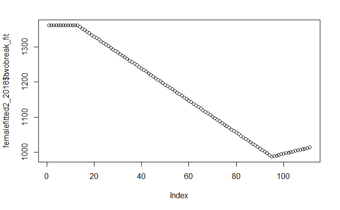

```r
plot(femalefitted2_2018$twobreak_fit)
```

## Combine male and female observed and predicted values for two break model

```r
femalefitted2_2018 %>%
  select(
    time, sex, observed = Rate,
    predicted = twobreak_fit
  ) %>%
  bind_rows(
    malefitted2_2018 %>%
      select(
        time, sex, observed = Rate,
        predicted = twobreak_fit
      )
  ) -> obs_fit_both_2018_2break
age <- "all"
obs_fit_both_2018_2break$agegroup = age
obs_fit_both_2018_2break
```

| time | sex | observed | predicted | agegroup |
| --- | --- | --- | --- | --- |
| 1990.875 | F | 1386.2 | 1362.8843 | all |
| 1991.125 | F | 1371.0 | 1362.8430 | all |
| 1991.375 | F | 1362.0 | 1362.8016 | all |
| 1991.625 | F | 1356.4 | 1362.7602 | all |
| 1991.875 | F | 1359.8 | 1362.7189 | all |
| 1992.125 | F | 1358.6 | 1362.6775 | all |
| 1992.375 | F | 1349.8 | 1362.6361 | all |
| 1992.625 | F | 1354.1 | 1362.5947 | all |
| 1992.875 | F | 1341.6 | 1362.5534 | all |
| 1993.125 | F | 1345.7 | 1362.5120 | all |

[output cut: 212 more lines]

# Extract breakpoint and calcuate 95% confidence intervals for two break model

```r
#CI for first male breakpoint
breakpoint1male_2018_2break <- my.seg_male2_2018$psi[3]
breakpoint1_SEmale_2018_2break <- my.seg_male2_2018$psi[5]
breakpoint1male_lowCI_2018_2break <- breakpoint1male_2018_2break - (breakpoint1_SEmale_2018_2break*1.96)
breakpoint1male_upCI_2018_2break <- breakpoint1male_2018_2break + (breakpoint1_SEmale_2018_2break*1.96)
breakpoint1male_2018_2break
```

```
[1] 1993.818
```

```r
breakpoint1male_lowCI_2018_2break
```

```
[1] 1992.77
```

```r
breakpoint1male_upCI_2018_2break
```

```
[1] 1994.865
```

```r
#CI for second male breakpoint
breakpoint2male_2018_2break <- my.seg_male2_2018$psi[4]
breakpoint2_SEmale_2018_2break <- my.seg_male2_2018$psi[6]
breakpoint2male_lowCI_2018_2break <- breakpoint2male_2018_2break - (breakpoint2_SEmale_2018_2break*1.96)
breakpoint2male_upCI_2018_2break <- breakpoint2male_2018_2break + (breakpoint2_SEmale_2018_2break*1.96)
breakpoint2male_2018_2break
```

```
[1] 2012.78
```

```r
breakpoint2male_lowCI_2018_2break
```

```
[1] 2012.002
```

```r
breakpoint2male_upCI_2018_2break
```

```
[1] 2013.559
```

```r
#CI for first female breakpoint
breakpoint1female_2018_2break <- my.seg_female2_2018$psi[3]
breakpoint1_SEfemale_2018_2break <- my.seg_female2_2018$psi[5]
breakpoint1female_lowCI_2018_2break <- breakpoint1female_2018_2break - (breakpoint1_SEfemale_2018_2break*1.96)
breakpoint1female_upCI_2018_2break <- breakpoint1female_2018_2break + (breakpoint1_SEfemale_2018_2break*1.96)
breakpoint1female_2018_2break
```

```
[1] 1993.851
```

```r
breakpoint1female_lowCI_2018_2break
```

```
[1] 1992.248
```

```r
breakpoint1female_upCI_2018_2break
```

```
[1] 1995.455
```

```r
breakpoint2female_2018_2break <- my.seg_female2_2018$psi[4]
breakpoint2_SEfemale_2018_2break <- my.seg_female2_2018$psi[6]
breakpoint2female_lowCI_2018_2break <- breakpoint2female_2018_2break - (breakpoint2_SEfemale_2018_2break*1.96)
breakpoint2female_upCI_2018_2break <- breakpoint2female_2018_2break + (breakpoint2_SEfemale_2018_2break*1.96)
breakpoint2female_2018_2break
```

```
[1] 2014.382
```

```r
breakpoint2female_lowCI_2018_2break
```

```
[1] 2013.357
```

```r
breakpoint2female_upCI_2018_2break
```

```
[1] 2015.408
```

## 2 break segmented plot

[figure not shown]

```r
segmentedplot_allage2break <- obs_fit_both_2018_2break %>%
  ggplot(
    aes (x=time, color=sex)
  ) +
  geom_point(
    aes (y=observed), alpha=0.4)+
  geom_line (
    aes (y=predicted), size=1) +
    ylim(0,2600)+
    labs(x="Year", y="Age-standardised mortality rate", title = "Age-standardised quarterly rolling annual mortality rates", subtitles="males and females, all ages, Scotland, 1990 to 2018: two-break segmented model fitted")+
 scale_x_continuous (breaks=c(1990, 1994, 1998, 2002, 2006, 2010, 2014, 2018))+
    geom_vline(xintercept = my.seg_male2_2018[["psi"]][[4]], color = "#00BFC4", linetype="dotdash")+
    geom_vline(xintercept = my.seg_female2_2018[["psi"]][[4]], color = "#F8766D", linetype="dotdash") +
    geom_vline(xintercept = my.seg_male2_2018[["psi"]][[3]], color = "#00BFC4", linetype="dotdash")+
    geom_vline(xintercept = my.seg_female2_2018[["psi"]][[3]], color = "#F8766D", linetype="dotdash") +
   annotate(geom="text", x=2011, y=300, label="Male\nbreakpoint 2\nOct 2012-\n Sep 2013 ")+
   annotate(geom="text", x=2017, y=300, label="Female\nbreakpoint 2\nJuly 2013-\nJune2014")+
  annotate(geom="text", x=1995, y=300, label="Male and Female\nbreakpoint 1\nJan 1990-\nDec 1990")
segmentedplot_allage2break
    ggsave (
    "Figures/segmentedplotonly_Scotland_Allages_2break.png", height=15, width=20, units="cm")
```

## Errorbar plot

Alternative way to indicate breakpoint, employing a point with error bars to indicate 95% confidence interval.

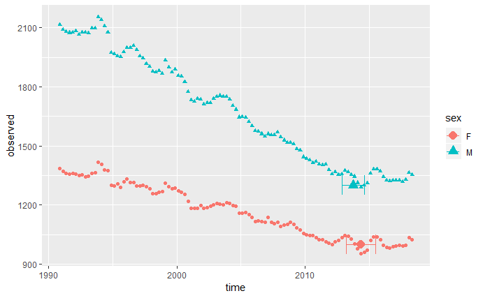

```r
obs_fit_both_2018 <- as_tibble(obs_fit_both_2018) # convert to 'nice' tibble format (better display)
temp_data <- tribble(
  ~ sex, ~time_min, ~time_max, ~y_pos,
  "M", breakpointmale_2018 - 2 * breakpoint_SEmale_2018, breakpointmale_2018 + 2 * breakpoint_SEmale_2018, 1300,
  "F", breakpointfemale_2018 - 2 * breakpoint_SEfemale_2018, breakpointfemale_2018 + 2 * breakpoint_SEfemale_2018, 1000
)
obs_fit_both_2018 %>%
   ggplot(
     aes(x = time, y = observed, color = sex, shape = sex)
     ) +
  geom_point(aes(y=observed)) +
  geom_errorbarh(
    aes(xmin = time_min, xmax = time_max, y = y_pos, colour = sex),
    inherit.aes = F,
    height = 100,
    data = temp_data
  ) +
  geom_point(
    aes(x = brkpoint, y = y_pos, shape = sex, color = sex),
    inherit.aes = F,
    data = tribble(
      ~ sex, ~brkpoint, ~y_pos,
      "M", breakpointmale_2018, 1300,
      "F", breakpointfemale_2018, 1000
    ),
    size = 4
  )
```

# Summary of breakpoints as box-and-whisker charts

```r
load("summary_stats_75andover.rdata") # for 75 and over
load("summary_stats_under75.rdata")
breakpoint_summaries_allage <- tribble(
  ~gender,  ~num_breaks, ~break_num, ~lower, ~upper, ~point,
  "Female", "One", 1, breakpoint_low_CIfemale_2018, breakpoint_up_CIfemale_2018, breakpointfemale_2018,
   "Male",   "One", 1, breakpoint_low_CImale_2018, breakpoint_up_CImale_2018, breakpointmale_2018,
   "Female", "Two", 1, breakpoint1female_lowCI_2018_2break[1], breakpoint1female_upCI_2018_2break[1], breakpoint1female_2018_2break[1],
   "Female", "Two", 2, breakpoint2female_lowCI_2018_2break[1], breakpoint2female_upCI_2018_2break[1], breakpoint2female_2018_2break[1],
   "Male",   "Two", 1, breakpoint1male_lowCI_2018_2break[1], breakpoint1male_upCI_2018_2break[1], breakpoint1male_2018_2break[1],
   "Male",   "Two", 2, breakpoint2male_lowCI_2018_2break[1], breakpoint2male_upCI_2018_2break[1], breakpoint2male_2018_2break[1]
)
breakpoint_summaries_over75 <- tribble(
  ~gender,  ~num_breaks, ~break_num, ~lower, ~upper, ~point,
  "Female", "One", 1, breakpoint_low_CIfemale_O75, breakpoint_up_CIfemale_O75, breakpointfemale_O75,
   "Male",   "One", 1, breakpoint_low_CImale_O75, breakpoint_up_CImale_O75, breakpointmale_O75,
   "Female", "Two", 1, breakpoint_low_CIfemale_O75_2break[1], breakpoint_up_CIfemale_O75_2break[1], breakpointfemale_O75_2break[1],
   "Female", "Two", 2, breakpoint_low_CIfemale_O75_2break[2], breakpoint_up_CIfemale_O75_2break[2], breakpointfemale_O75_2break[2],
   "Male",   "Two", 1, breakpoint_low_CImale_O75_2break[1], breakpoint_up_CImale_O75_2break[1], breakpointmale_O75_2break[1],
   "Male",   "Two", 2, breakpoint_low_CImale_O75_2break[2], breakpoint_up_CImale_O75_2break[2], breakpointmale_O75_2break[2]
)
breakpoint_summaries_upto75 <- tribble(
  ~gender,  ~num_breaks, ~break_num, ~lower, ~upper, ~point,
  "Female", "One", 1, breakpoint_low_CIfemale_U75, breakpoint_up_CIfemale_U75, breakpointfemale_U75,
   "Male",   "One", 1, breakpoint_low_CImale_U75, breakpoint_up_CImale_U75, breakpointmale_U75,
   "Female", "Two", 1, breakpoint_low_CIfemale_U75_2break[1], breakpoint_up_CIfemale_U75_2break[1], breakpointfemale_U75_2break[1],
   "Female", "Two", 2, breakpoint_low_CIfemale_U75_2break[2], breakpoint_up_CIfemale_U75_2break[2], breakpointfemale_U75_2break[2],
   "Male",   "Two", 1, breakpoint_low_CImale_U75_2break[1], breakpoint_up_CImale_U75_2break[1], breakpointmale_U75_2break[1],
   "Male",   "Two", 2, breakpoint_low_CImale_U75_2break[2], breakpoint_up_CImale_U75_2break[2], breakpointmale_U75_2break[2]
)
breakpoint_summaries_allage
```

| gender | num_breaks | break_num | lower | upper | point |
| --- | --- | --- | --- | --- | --- |
| Female | One | 1 | 2013.266 | 2015.483 | 2014.374 |
| Male | One | 1 | 2012.918 | 2014.628 | 2013.773 |
| Female | Two | 1 | 1992.248 | 1995.455 | 1993.851 |
| Female | Two | 2 | 2013.357 | 2015.408 | 2014.382 |
| Male | Two | 1 | 1992.770 | 1994.865 | 1993.818 |
| Male | Two | 2 | 2012.002 | 2013.559 | 2012.780 |

```r
breakpoint_summaries_over75
```

| gender | num_breaks | break_num | lower | upper | point |
| --- | --- | --- | --- | --- | --- |
| Female | One | 1 | 2012.493 | 2016.621 | 2014.557 |
| Male | One | 1 | 2012.994 | 2015.224 | 2014.109 |
| Female | Two | 1 | 2001.945 | 2006.732 | 2004.338 |
| Female | Two | 2 | 2010.189 | 2013.287 | 2011.738 |
| Male | Two | 1 | 1992.370 | 1994.877 | 1993.623 |
| Male | Two | 2 | 2011.570 | 2013.891 | 2012.731 |

```r
breakpoint_summaries_upto75
```

| gender | num_breaks | break_num | lower | upper | point |
| --- | --- | --- | --- | --- | --- |
| Female | One | 1 | 2011.856 | 2013.159 | 2012.508 |
| Male | One | 1 | 2012.844 | 2014.073 | 2013.458 |
| Female | Two | 1 | 2003.025 | 2008.725 | 2005.875 |
| Female | Two | 2 | 2013.682 | 2015.080 | 2014.381 |
| Male | Two | 1 | 1993.273 | 1995.043 | 1994.158 |
| Male | Two | 2 | 2012.458 | 2013.464 | 2012.961 |

```r
breakpoint_summaries_all <- breakpoint_summaries_allage %>%
  mutate(age_group = "All ages") %>%
  bind_rows(
    breakpoint_summaries_over75 %>% mutate(age_group = "75 years and over")
  ) %>%
  bind_rows(
    breakpoint_summaries_upto75 %>% mutate(age_group = "Up to 75 years")
  )
breakpoint_summaries_all <- breakpoint_summaries_all %>%
  mutate(age_group = factor(age_group, levels = c("All ages", "Up to 75 years", "75 years and over")))
```

Now let’s visualise this

Now let’s think about labelling/describing to take into account the use of quarterly rolling values

[figure not shown]

```r
write_yearquarter <- function(x){
  df <- data_frame(
    x = x, floor = floor(x)
  ) %>%
    mutate(remainder = x - floor) %>%
    mutate(quarter = 1 + floor(4 * remainder)) %>%
    mutate(label = paste0("Q", quarter, ", ", floor))

  pull(df, label)
}
breakpoint_summaries_all %>%
  arrange(num_breaks, gender, age_group) %>%
  mutate(model_name = paste0(gender, ", ", num_breaks, " break. ", age_group)) %>%
  mutate(rownum = row_number()) %>%
  mutate(model_name = fct_reorder(model_name, rownum, .desc = TRUE)) %>%
  mutate(
    lower_label = write_yearquarter(lower - 1),
    upper_label = write_yearquarter(upper),
    point_label = write_yearquarter(point - 0.5),
    both_label = paste0(lower_label, " to ", upper_label)
    ) %>%
  ggplot(aes(y = model_name)) +
  geom_point(aes(x = point)) +
  geom_segment(aes(yend = model_name, x = lower, xend = upper)) +
  theme_minimal(base_size = 18) +
  labs(
    x = "Year", y = "Sex, model type, age group",
    title = "Segmented regression of age-standardised mortality rates for Scotland Q4 1990- Q2 2018:
              breakpoint estimates for males and females, one and two break models",
    subtitle = "Dots indicate point estimates; lines indicate 95% confidence interval"
       ) +
  coord_fixed(ratio = 2) +
  geom_text(aes(x = point, label = point_label), nudge_y = 0.3, fontface = "bold") +
  geom_text(aes(x = point, label = both_label), nudge_y = -0.2, fontface = "italic") +
  scale_x_continuous(limits = c(1988, 2018), breaks = seq(1990, 2018, by = 2), minor_breaks = seq(1984, 2018, by = 1))

ggsave("figures/breakpoint_timeline.png", width = 50, height = 30, dpi = 300, units = "cm")
```

This might be a bit of a Phyrric victory, but seems to do the job.